# Data for MJC FTCA report

## mutating

lets mutate mega_data to add a column floor_date that marks the first day of the month that a claim was paid out. This will allow us-hopefully- to create graphs that count the number of claims in a given month in a given year. It’s not the most elegant solution but its the only one I could find.

```r
mega_data<-mega_data |>
  mutate(
    floor_date = floor_date(payment_sent_date, "month")
  )
```

Lets mutate again to add another new variable: citation_cause. This will be a simplified version of principle_citation_code, containing the information about the ‘why’ of the payment (eg med_mal or prop_seize) but not the how (admin or through the courts). The latter information is (with slightly less specificity) already contained in judgement_type_code_anyway

```r
mega_data <- mega_data |>
  mutate(
    citation_cause = case_when(
      principle_citation_code %in% c("28-USC-2677 Traffic","28-USC-2672 Traffic","28 USC 1346(b) Traffic") ~ "traffic",
      principle_citation_code %in% c("28 USC 1346(b) Fls-Arrest","28-USC-2677 Fls-Arrest","28-USC-2672 Fls-Arrest") ~ "fls_arrest",
      principle_citation_code %in% c("28-USC-2677 Med Mal","28-USC-2672 Med Mal") ~ "med_mal",
      principle_citation_code %in% c("28 USC 1346(b) Prop-Maint", "28-USC-2672 Prop-Maint","28-USC-2677 Prop-Maint") ~ "prop_maint",
      principle_citation_code %in% c("28-USC-2672  Fire-Flood") ~ "fire_flood",
      principle_citation_code %in% c("28-USC-2672 Prop-Seize", "28 USC 1346(b) Prop-Seize", "28-USC-2677 Prop-Seize") ~ "prop_seize",
      principle_citation_code %in% c("28-USC-2677 Miscellany", "28-USC-2672 Miscellany","28 USC 1346(b) Miscellany") ~ "miscellany",
      principle_citation_code %in% c("28-USC-2672 Aircrash") ~ "aircrash"
     )
  )
```

## summary statistics

```r
mega_data_summary <- mega_data%>%
  group_by(floor_date) %>%
    summarize(count = n_distinct(payment_id_number),
              payment_amount_sum = sum(payment_amount),
              payment_amount_median = median(payment_amount)
    )

mega_data_summary_by_citation_cause <- mega_data|>
  group_by(floor_date, citation_cause)|>
  summarize(count = n_distinct(payment_id_number),
              payment_amount_sum = sum(payment_amount),
              payment_amount_median = median(payment_amount))
```

[output not shown]

## graphing

now let’s try to create some line graphs tracking changes in each of these statistics over time

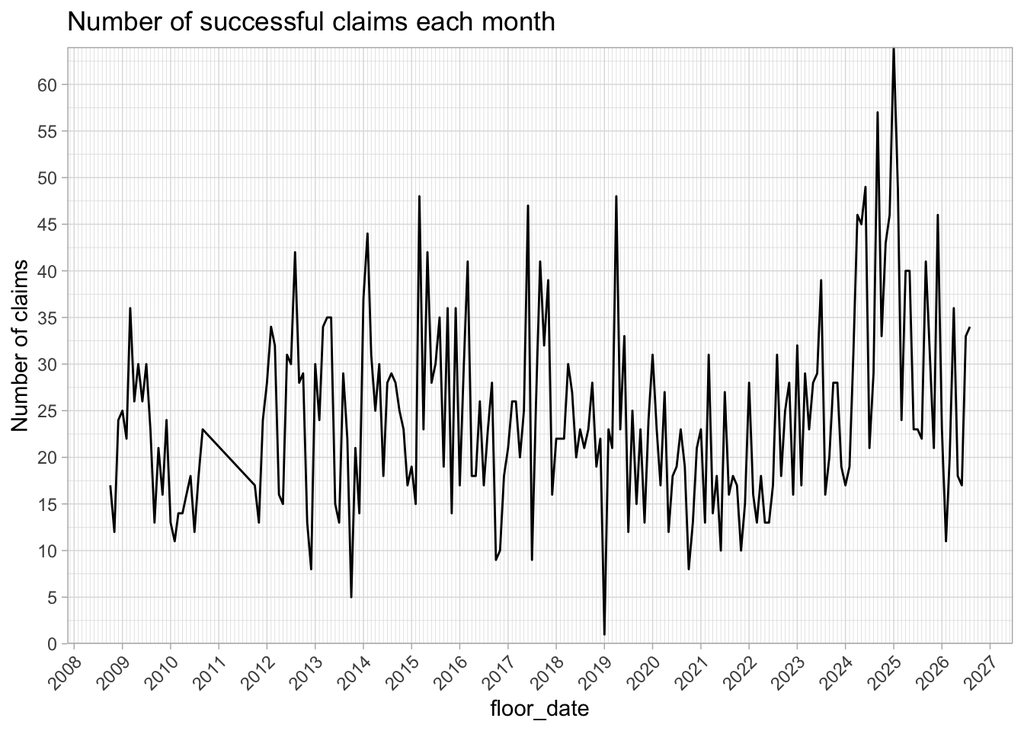

```r
#count of claims paid each month over time

ggplot(mega_data_summary, aes(x = floor_date, y = count)) +
  geom_line()+
  scale_y_continuous(breaks = scales::pretty_breaks(n = 10), name = "Number of claims",
                     expand = c(0, 0), limits = c(0, NA))+
  scale_x_date(date_breaks = "1 year", date_minor_breaks = "1 month", labels = scales::label_date_short())+
  theme_light()+
  theme(axis.text.x = element_text(angle = 45, vjust = 1, hjust=1)) +
  ggtitle("Number of successful claims each month")
```

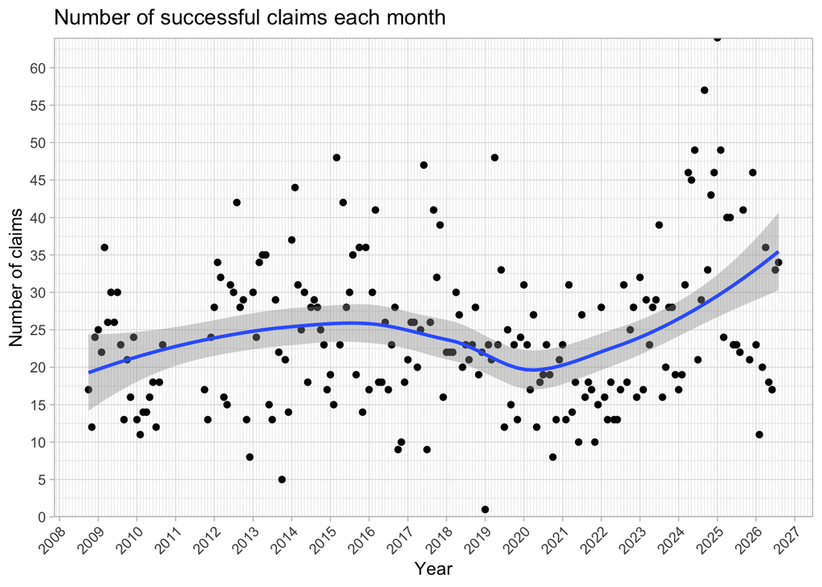

```r
#alternative look
ggplot(mega_data_summary, aes(x = floor_date, y = count)) +
  geom_point()+
  geom_smooth()+
  scale_y_continuous(breaks = scales::pretty_breaks(n = 10), name = "Number of claims",
                     expand = c(0, 0), limits = c(0, NA))+
  scale_x_date(date_breaks = "1 year", date_minor_breaks = "1 month", labels = scales::label_date_short(), name = "Year")+
  theme_light()+
  theme(axis.text.x = element_text(angle = 45, vjust = 1, hjust=1)) +
  ggtitle("Number of successful claims each month")
```

out of curiosity i wonder how the median payment amount has changed over time

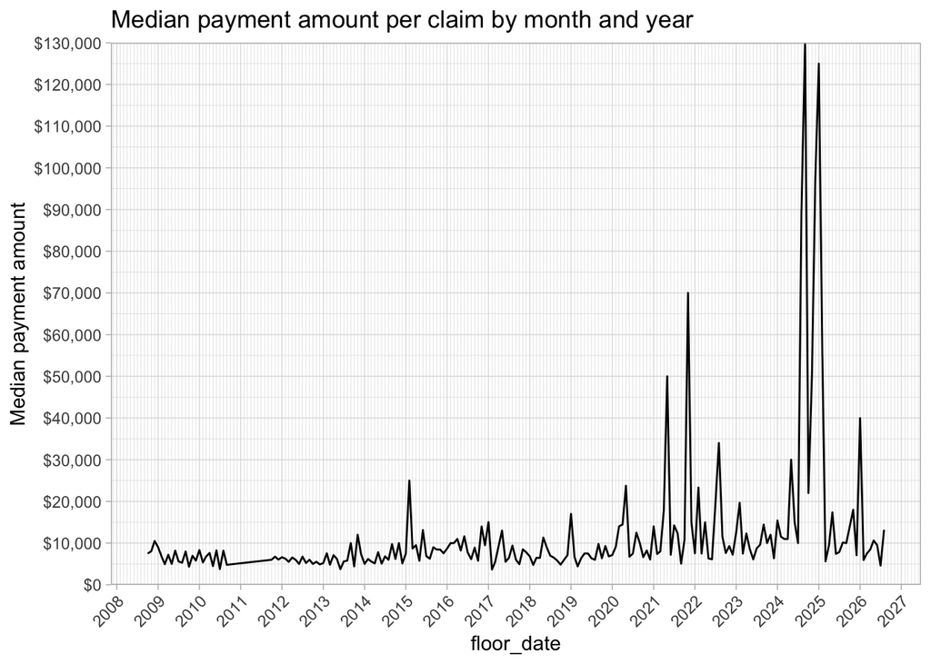

```r
ggplot(mega_data_summary, aes(x = floor_date, y = payment_amount_median)) +
  geom_line()+
  scale_y_continuous(breaks = scales::pretty_breaks(n = 10), name = "Median payment amount",
                     expand = c(0, 0), limits = c(0, NA), labels = scales::label_dollar())+
  scale_x_date(date_breaks = "1 year", date_minor_breaks = "1 month", labels = scales::label_date_short())+
  theme_light()+
  theme(axis.text.x = element_text(angle = 45, vjust = 1, hjust=1)) +
  ggtitle("Median payment amount per claim by month and year")
```

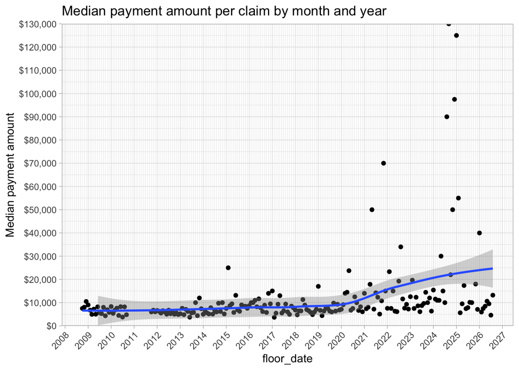

```r
ggplot(mega_data_summary, aes(x = floor_date, y = payment_amount_median)) +
  geom_point()+
  geom_smooth()+
  scale_y_continuous(breaks = scales::pretty_breaks(n = 10), name = "Median payment amount",
                     expand = c(0, 0), limits = c(0, NA), labels = scales::label_dollar())+
  scale_x_date(date_breaks = "1 year", date_minor_breaks = "1 month", labels = scales::label_date_short())+
  theme_light()+
  theme(axis.text.x = element_text(angle = 45, vjust = 1, hjust=1)) +
  ggtitle("Median payment amount per claim by month and year")
```

Those 2025 spikes must be the child seperation payments

im addicted, lets do the monthly totals over time

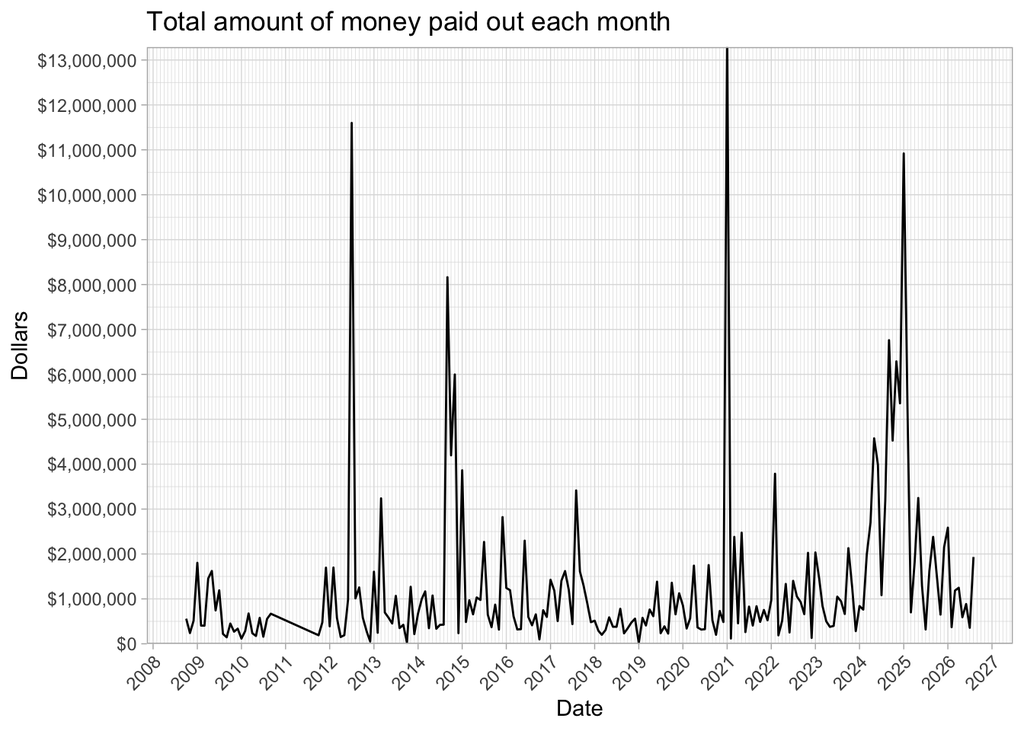

```r
ggplot(mega_data_summary, aes(x = floor_date, y = payment_amount_sum)) +
  geom_line()+
  scale_y_continuous(breaks = scales::pretty_breaks(n = 10), name = "Dollars",
                     expand = c(0, 0), limits = c(0, NA), labels = scales::label_dollar())+
  scale_x_date(date_breaks = "1 year", date_minor_breaks = "1 month", labels = scales::label_date_short(), name = "Date")+
  theme_light()+
  theme(axis.text.x = element_text(angle = 45, vjust = 1, hjust=1)) +
  ggtitle("Total amount of money paid out each month")
```

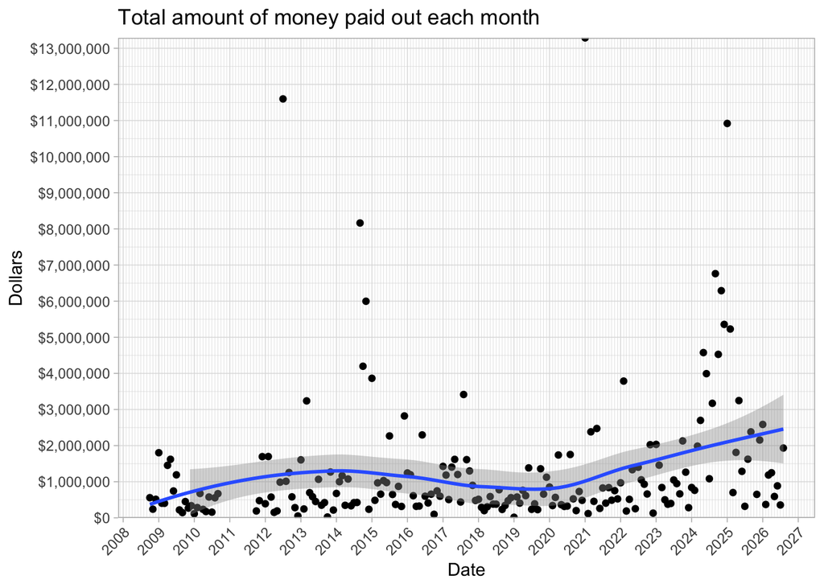

```r
ggplot(mega_data_summary, aes(x = floor_date, y = payment_amount_sum)) +
  geom_point()+
  geom_smooth()+
  scale_y_continuous(breaks = scales::pretty_breaks(n = 10), name = "Dollars",
                     expand = c(0, 0), limits = c(0, NA), labels = scales::label_dollar())+
  scale_x_date(date_breaks = "1 year", date_minor_breaks = "1 month", labels = scales::label_date_short(), name = "Date")+
  theme_light()+
  theme(axis.text.x = element_text(angle = 45, vjust = 1, hjust=1)) +
  ggtitle("Total amount of money paid out each month")
```

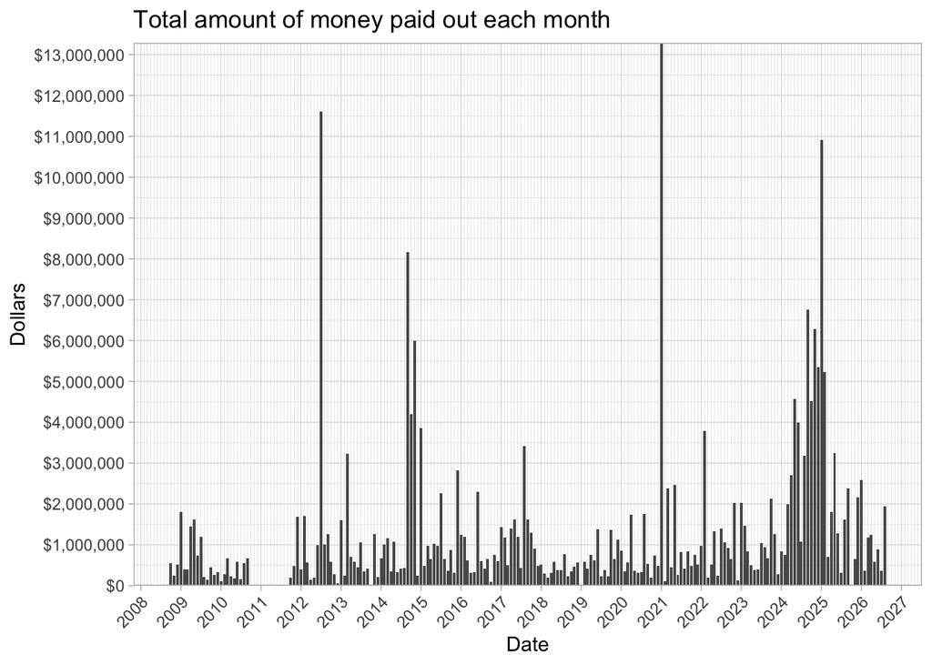

```r
ggplot(mega_data_summary, aes(x = floor_date, y = payment_amount_sum)) +
  geom_col()+
  scale_y_continuous(breaks = scales::pretty_breaks(n = 10), name = "Dollars",
                     expand = c(0, 0), limits = c(0, NA), labels = scales::label_dollar())+
  scale_x_date(date_breaks = "1 year", date_minor_breaks = "1 month", labels = scales::label_date_short(), name = "Date")+
  theme_light()+
  theme(axis.text.x = element_text(angle = 45, vjust = 1, hjust=1)) +
  ggtitle("Total amount of money paid out each month")
```

huh, that last spike is interesting… lets zoom in by narrowing our data to the past 5 years

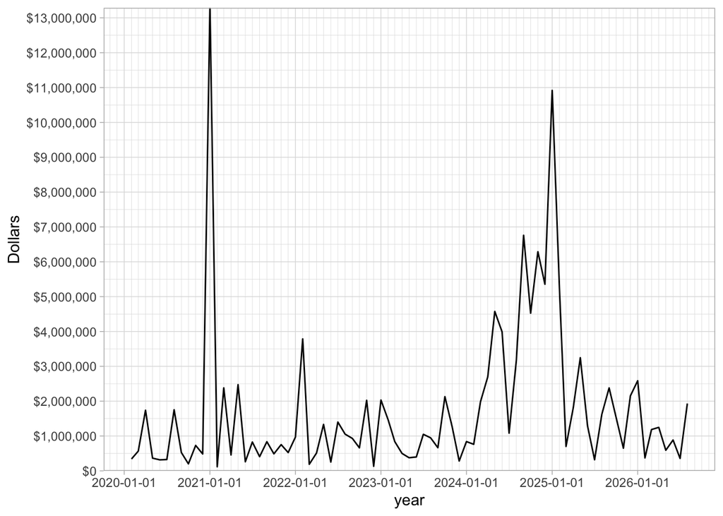

```r
mega_data_summary |>
  filter(floor_date > ymd("2020-01-01"))|>
  ggplot(aes(x = floor_date, y = payment_amount_sum)) +
    geom_line()+
    scale_y_continuous(breaks = scales::pretty_breaks(n = 10), name = "Dollars",
                       expand = c(0, 0), limits = c(0, NA), labels = scales::label_dollar())+
    scale_x_date(date_breaks = "1 year", date_minor_breaks = "1 month", name = "year")+
    theme_light()
```

```r
    #this plot needs some more work to make it pretty but for now its interesteing
```

playing around:all payments, color coded by kind

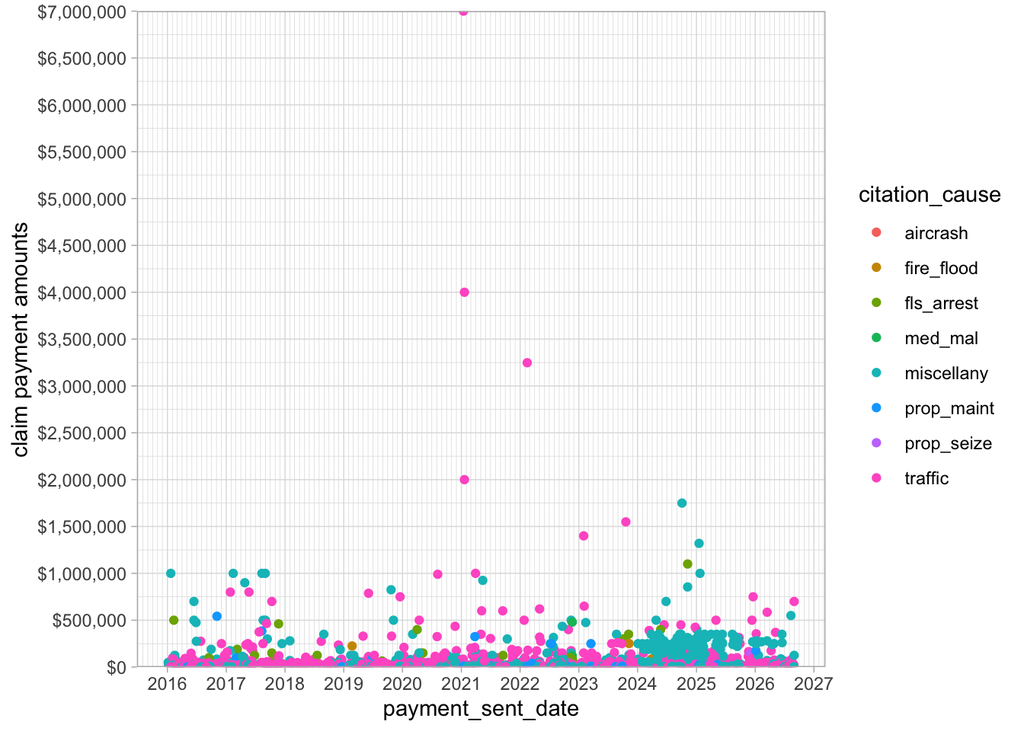

```r
mega_data |>
  filter(payment_sent_date> ymd("2016-01-01"))|>
  ggplot(aes(x = payment_sent_date, y = payment_amount, color = citation_cause)) +
    geom_point()+
    scale_y_continuous(breaks = scales::pretty_breaks(n = 10), name = "claim payment amounts",
                       expand = c(0, 0), limits = c(0, NA), labels = scales::label_dollar())+
    scale_x_date(date_breaks = "1 year", date_minor_breaks = "1 month", labels = scales::label_date_short())+
    theme_light()
```

```r
#needs work to look better; will come back to it
```

lets play around with our second summary stastic table and group some stuff by kind

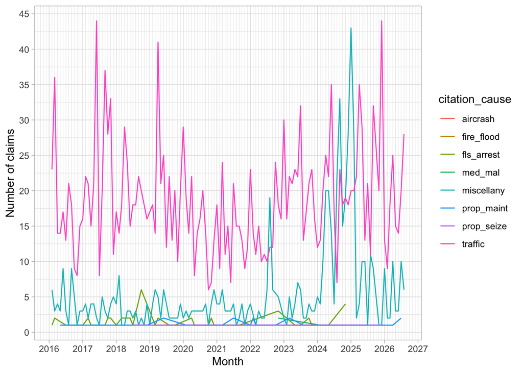

```r
#line graph of number of claims per month over time, color = citation cause
mega_data_summary_by_citation_cause |>
  filter(floor_date > ymd("2016-01-01"))|>
    ggplot(aes(x = floor_date, y = count, color = citation_cause))+
    geom_line()+
    scale_y_continuous(breaks = scales::pretty_breaks(n = 10), name = "Number of claims")+
    scale_x_date(date_breaks = "1 year", date_minor_breaks = "1 month", labels = scales::label_date_short(), name = "Month")+
    theme_light()
```

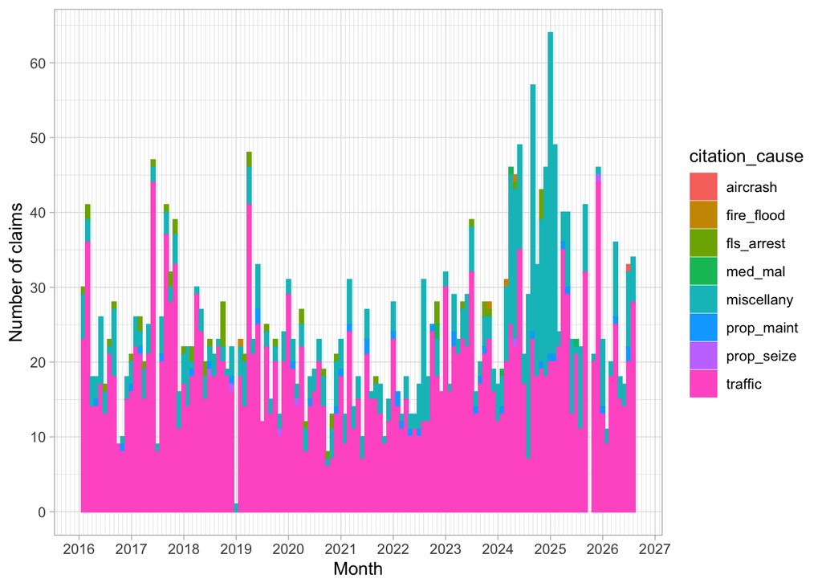

```r
#bar graph of number of claims per month over time, color = citation cause
mega_data_summary_by_citation_cause |>
  filter(floor_date > ymd("2016-01-01"))|>
    ggplot(aes(x = floor_date, y = count, color = citation_cause, fill = citation_cause))+
    geom_col()+
    scale_y_continuous(breaks = scales::pretty_breaks(n = 10), name = "Number of claims")+
    scale_x_date(date_breaks = "1 year", date_minor_breaks = "1 month", labels = scales::label_date_short(), name = "Month")+
    theme_light()
```

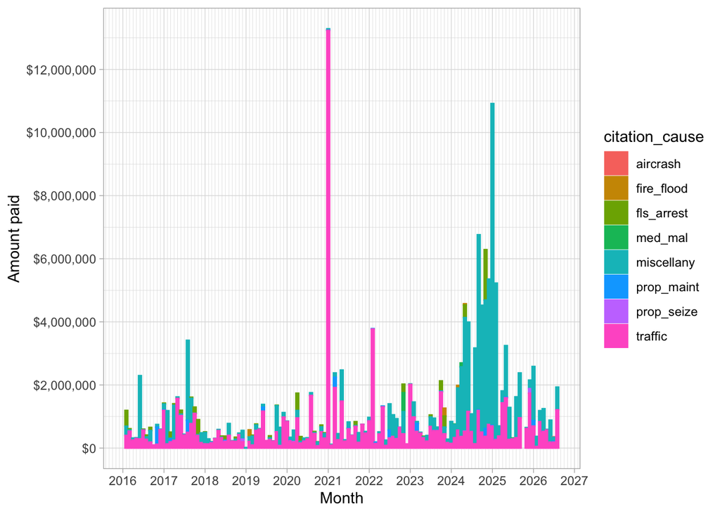

```r
#bar chart of payment amounts by year and citation cause
mega_data_summary_by_citation_cause |>
  filter(floor_date > ymd("2016-01-01"))|>
    ggplot(aes(x = floor_date, y = payment_amount_sum, color = citation_cause, fill = citation_cause))+
    geom_col()+
    scale_y_continuous(breaks = scales::pretty_breaks(n = 10), name = "Amount paid", label = scales::label_dollar())+
    scale_x_date(date_breaks = "1 year", date_minor_breaks = "1 month", labels = scales::label_date_short(), name = "Month")+
    theme_light()
```

```r
#come back and do y axis as money
```

some attempts at visualizing payment amounts by citation cause- this info is, or may be, of some practical value to lawyers seeking to sue through the ftca, so I want it to be legible

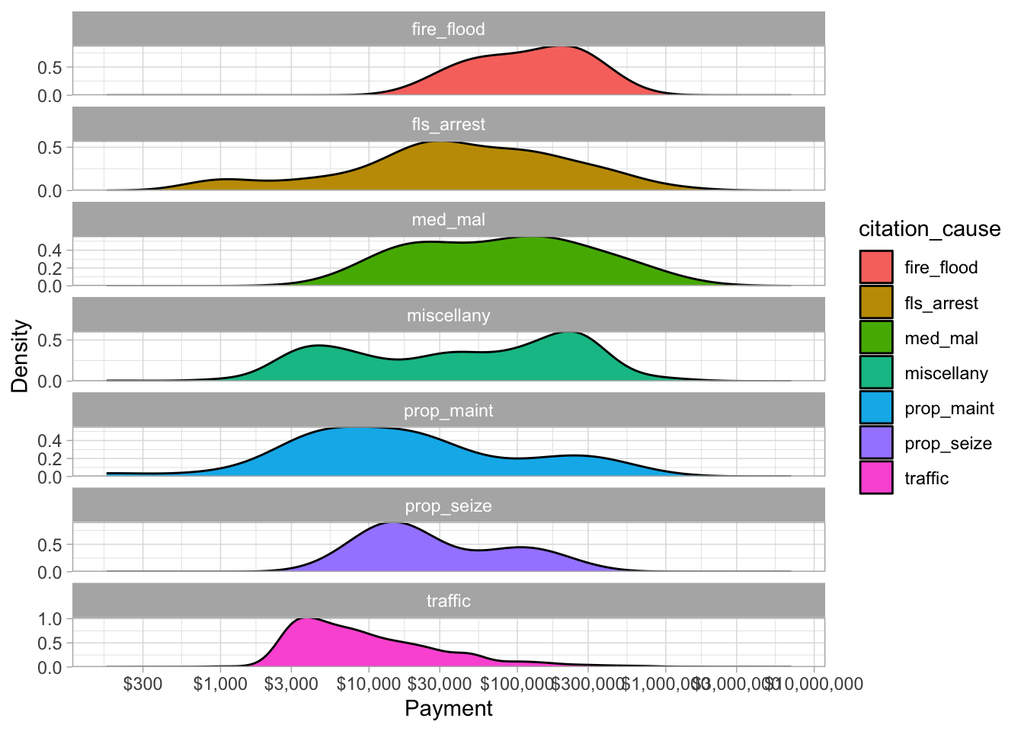

```r
# #facet wrapped histogram
# ggplot(mega_data, aes(x=payment_amount, fill=citation_cause))+
#   geom_histogram()+
#   scale_x_log10(labels = scales::label_dollar(), name = "payment amount") + #i had to scale the x axis by log in order to make anything at all visible, but it wasn't what i had in mind and i would rather not have
#   facet_wrap(~citation_cause, scales = "free_y", ncol=1)
# #this is pretty good but rstudio is making it tiny and squished for some reason
#
# #layered transparent density plots
# ggplot(mega_data, aes(x = payment_amount, color = citation_cause, fill = citation_cause)) +
#   scale_x_log10(labels = scales::label_dollar()) +
#   geom_density(alpha = 0.5)
# #this is pretty but close to useless

#maybe the solution is a facet wrapped density plot?
# i ended up liking this the best so I'm reducing it to just the past 10 years, getting rid of the empty 'aircrash' cause, and adding some visual elements
mega_data|>
  filter(floor_date > ymd("2016-01-01"), citation_cause!="aircrash")|>
  ggplot(aes(x=payment_amount, fill=citation_cause))+
    geom_density()+
    scale_x_log10(labels = scales::label_dollar(), breaks = scales::breaks_log(n = 8), name = "Payment") + #i had to scale the x axis by log in order to make anything at all visible, but it wasn't what i had in mind and i would rather not have
    facet_wrap(~citation_cause, scales = "free_y", ncol=1)+
    scale_y_continuous(breaks = scales::pretty_breaks(n = 2), name = "Density", expand = c(0, 0), limits = c(0, NA))+
    theme_light()
```

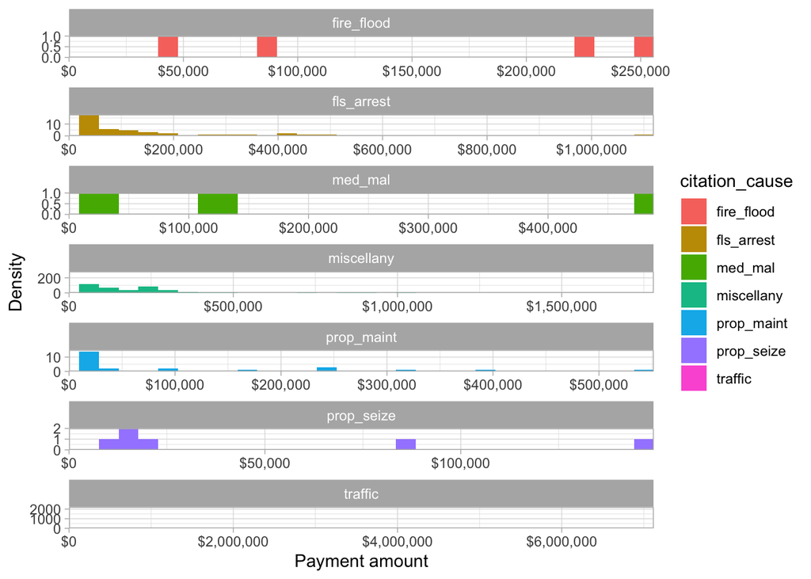

```r
#an alternative without the log scale x axis and in fact without a shared x axis at all
mega_data|>
  filter(floor_date > ymd("2016-01-01"), citation_cause!="aircrash")|>
  ggplot(aes(x=payment_amount, fill=citation_cause))+
    geom_histogram()+ # i switched to a histogram and it made me realize the density plot might be misleading...
    facet_wrap(~citation_cause, scales = "free", ncol=1)+ #scales are free bcs otherwise things are too different
    scale_x_continuous(breaks = scales::pretty_breaks(n = 4), name = "Payment amount", expand = c(0, 0), limits = c(0, NA), labels = scales::label_dollar())+
    scale_y_continuous(breaks = scales::pretty_breaks(n = 2), name = "Density", expand = c(0, 0), limits = c(0, NA))+
    theme_light()
```

```r
#needs thought about histogram v density, work to fix squishing and legend, add title, etc. aesthetically
```

I think the reason that the histograms are so split might be because we’re looking at both litigative and administrative payments.lets split those up.

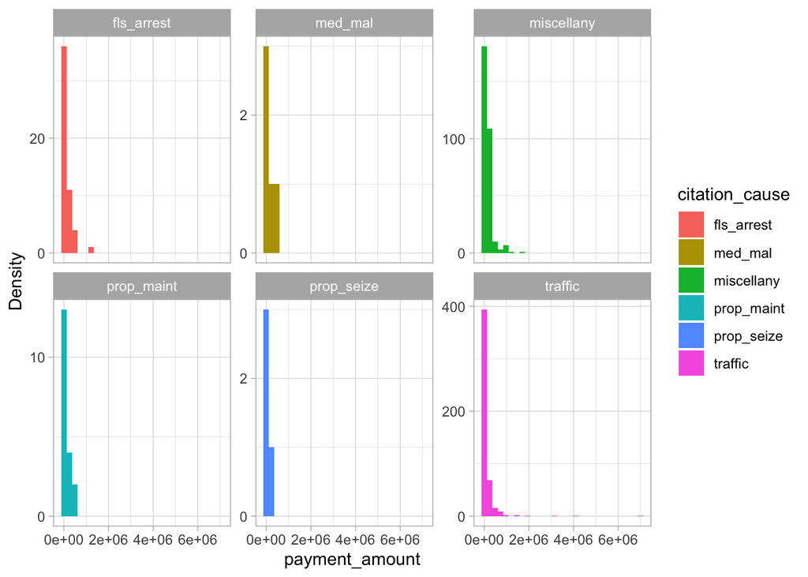

```r
mega_data|>
  filter(floor_date > ymd("2016-01-01"), citation_cause!="aircrash", judgment_type_code=="Litigative")|>
  ggplot(aes(x=payment_amount, fill=citation_cause))+
    geom_histogram()+
    #scale_x_log10(labels = scales::label_dollar(), breaks = scales::breaks_log(n = 8), name = "Payment") + #i had to scale the x axis by log in order to make anything at all visible, but it wasn't what i had in mind and i would rather not have
    facet_wrap(~citation_cause, scales = "free_y")+
    scale_y_continuous(breaks = scales::pretty_breaks(n = 2), name = "Density")+
    theme_light()
```

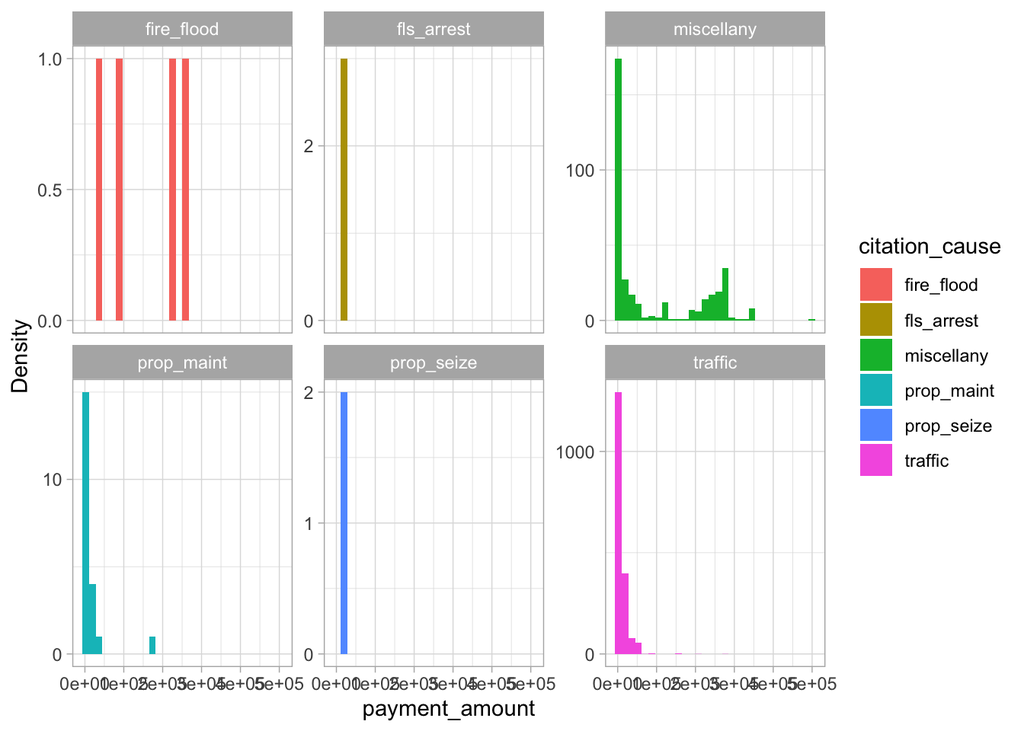

```r
mega_data|>
  filter(floor_date > ymd("2016-01-01"), citation_cause!="aircrash", judgment_type_code=="Administrative")|>
  ggplot(aes(x=payment_amount, fill=citation_cause))+
    geom_histogram()+
    #scale_x_log10(labels = scales::label_dollar(), breaks = scales::breaks_log(n = 8), name = "Payment") + #i had to scale the x axis by log in order to make anything at all visible, but it wasn't what i had in mind and i would rather not have
    facet_wrap(~citation_cause, scales = "free_y")+
    scale_y_continuous(breaks = scales::pretty_breaks(n = 2), name = "Density")+
    theme_light()
```

```r
#this is getting frustrating... i dont know why the axes are so huge when ostensibly there is no data on the upper ends. argh. Needs more work
```

Now I want to try represnting this in a very different way

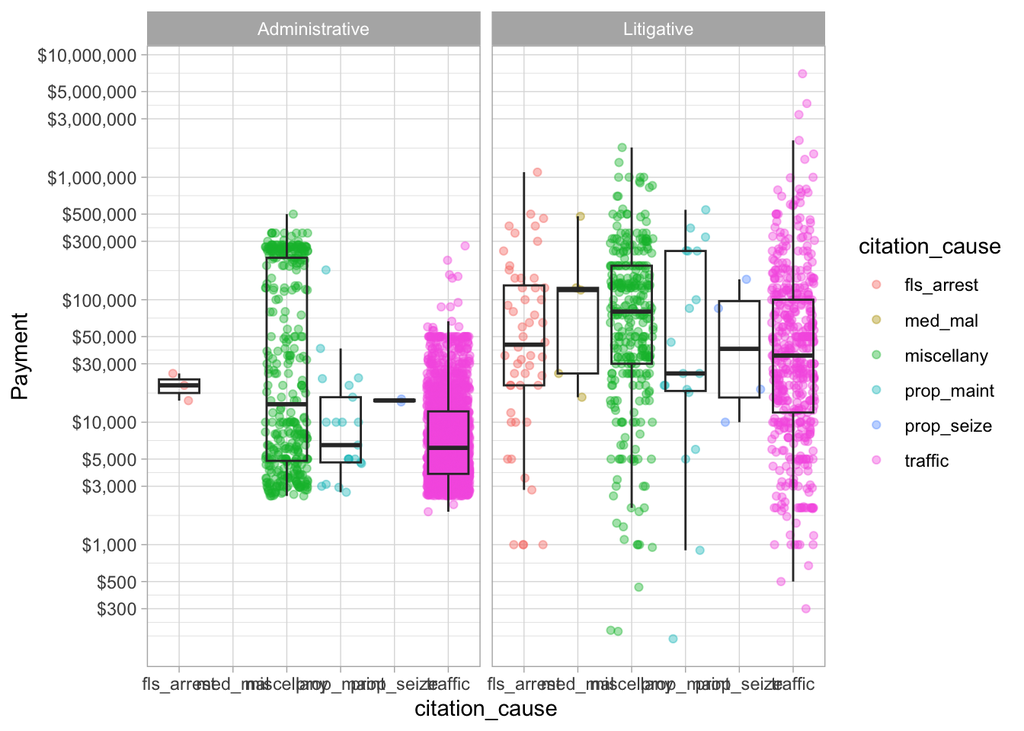

```r
mega_data|>
  filter(floor_date > ymd("2016-01-01"), citation_cause!="aircrash", citation_cause!="fire_flood")|>
  #sorry to aircrash and fire flood but they're not what we're the most interested in anyway and there arent that many examples in our timeframe
  ggplot(aes(x = citation_cause, y=payment_amount))+
  geom_jitter(alpha = 0.4, aes(color = citation_cause)) +
  geom_boxplot(alpha = 0) +
  facet_wrap(~judgment_type_code, scales = "fixed")+
  scale_y_log10(labels = scales::label_dollar(), breaks = scales::breaks_log(n = 15), name = "Payment")+
  theme_light()
```

```r
#needs some work on legend etc but i think pretty good
```

TO DO:

- scatter plot with jitter and alpha, x axis is citation code, y axis is payment amount, boxplot/violin plot superimposed [done]
- admin vs judicially awarded over time
- create codebook
- stacked bar by year and citation cause,[done]
- fix histograms
- filled bar payment amount over time color os citation code

-> one of the big stories here is that the stuff they’re describing as traffic and misc cannot possibly be